# 의학통계학-과제 2 - 답안

### 1. 교재 연습문제 4장 1번 (102 page) - SAS 를 이용하시오.

로지스틱 회귀식을 적합하면 다음과 같은 결과가 나온다 (따로 첨부한 SAS 결과화일을 참조하세요). 성공의 확률, 즉 $P(Y=1)$은 구속이 되는 사건의 확률이다. 독립변수는 $x_1$=거주여부(예=1, 아니오=-1), $x_2$=체포경력 (예=1, 아니오=-1)이다.

$$logit [P(Y=1 |x_1, x_2)] = -1.4828 - 0.2960 x_1 +0.1735 x_2$$

$$P(Y=1 |x_1, x_2) = \frac{\exp(-1.4828 - 0.2960 x_1 +0.1735 x_2)}{1+ \exp(-1.4828 - 0.2960 x_1 +0.1735 x_2)}$$

위의 결과를 이용하는 다음과 같은 결과를 얻은다.

- 거주=아니오, 체포경력=아니오

$$P(Y=1 |x_1=-1, x_2=-1) = \frac{\exp(-1.4828 + 0.2960 -0.1735 )}{1+ \exp(-1.4828+ 0.2960 -0.1735 )} = 0.2042$$

- 거주=예 , 체포경력=아니오

$$P(Y=1 |x_1=1, x_2=-1) = \frac{\exp(-1.4828 - 0.2960 -0.1735 )}{1+ \exp(-1.4828-0.2960 -0.1735 )} = 0.1243$$

- 거주=아니오 , 체포경력=예

$$P(Y=1 |x_1=-1, x_2=1) = \frac{\exp(-1.4828 + 0.2960 +0.1735 )}{1+ \exp(-1.4828+ 0.2960 +0.1735 )} = 0.2663$$

- 거주=예 , 체포경력=예

$$P(Y=1 |x_1=1, x_2=1) = \frac{\exp(-1.4828 - 0.2960 + 0.1735 )}{1+ \exp(-1.4828- 0.2960 +0.1735 )} = 0.1672$$

도시 거주의 여부에 대한 오즈비는 다음과 같다.

$$\frac{\frac{P(Y=1 |x_1=1, x_2=-1) }{1-P(Y=1 |x_1=1, x_2=-1) }} {\frac{P(Y=1 |x_1=-1, x_2=-1) }{1-P(Y=1 |x_1=-1, x_2=-1) } } = \frac{ \tfrac{0.1243}{1-0.1243} } { \tfrac{0.2042}{1-0.2042}} =0.553$$

위의 결과를 보면 도시에 거주하는 사람의 오즈가 거주하지 않는 사람의 오즈의 1/2로 나타남을 알 수 있다. 즉 도시에 거주하면 구속될 확률이 낮아진다.

체포경력의 여부에 대한 오즈비는 다음과 같다.

$$\frac{\frac{P(Y=1 |x_1=1, x_2=1 }{1-P(Y=1 |x_1=1, x_2=1) }} {\frac{P(Y=1 |x_1=1, x_2=-1) }{1-P(Y=1 |x_1=1, x_2=-1) } } = \frac{ \tfrac{0.1672}{1-0.1672} } { \tfrac{0.1243}{1-0.1243}} = 1.414$$

위의 결과를 보면 체포경력이 있는 사람의 오즈가 없는 사람의 오즈의 1.4배로 나타남을 알 수 있다. 즉 체포경력이 있으면 구속될 확률이 높아진다.

### 2. 폐암 자료

100명의 사람들을 흡연자($x=1$)과 비흡연자($x=0$)의 그룹으로 나누었을 떄 각 그룹에서 폐암이 발병한 사람($y=1$)과 없는 사람($y=0$)의 수가 표 에 주어져있다. 페암의 발병여부를 반응변수 $y=0,1$로하고 흡연의 여부를 독립변수 $x=0,1$로 하자.

흡연과 폐암의 관계

| 폐암/흡연 | 흡연 ($x=1$) | 비흡연 ($x=0$) | 합 |
| --- | --- | --- | --- |
| 폐암 있음 ($y=1$) | 9 | 5 | 14 |
| 폐암 없음 ($y=0$) | 46 | 40 | 86 |
| 합 | 55 | 45 | 100 |

1. SAS 을 이용하여 로지스틱 회귀식을 적합하고 결과를 설명하시오.
2. 위의 실험에서 흡연/비흡연 그룹의 폐암 발병확률에 대한 Odds ratio를 구하시오.
3. 위에서 구한 회귀계수의 추정치와 Odds ratio의 관계를 설명하시오.

회귀식의 결과는 다음과 같다.

$$logit P(Y=1| x) = \hat \beta_0 + \hat \beta_1 x = -1.8553+ 0.2239 x$$

위의 식에서 $Y=1$인 사건은 폐암이 있는 사건이고 비흡연은 $x=-1$, 흡연은 $x=1$이다. 위의 식에서 흡연자와 비흡연자에 대한 오즈비는 1.565 이다.

$$oddratio = \exp(2*\hat \beta_1) = \exp(2*0.2239) = 1.565$$

### 3. 자동차 구입 자료

새차 구입에 대한 소비자의 행태을 조사하기 위하여 20개의 가구를 선택하여 다음과 같은 변수에 대한 자료를 수집하였다.
$$\begin{align*}
x_1 &= \text{가구 1년 소득, 단위는 백만원} \\
x_2 &= \text {보유한 차량 중 가장 오래된 차의 보유기간, 단위는 년}
\end{align*}$$
위의 두변수에 대한 자료를 수집한 뒤 6개월이 지난 후에 새차를 구입하였는지에 대한 여부를 조사하였다. 변수 $y$는 만약 새차를 구입했다면 $y=1$로 하고 아니면 $y=0$으로 정의하였다. $y$를 반응변수로 하고 $x_1$과 $x_2$를 예측변수로 하는 로지스틱 회귀식을 고려해보자.

자료는 아래의 부록에 주어져 있다.

1. SAS 을 이용하여 로지스틱 회귀식을 적합하고 확률을 예측하는 회귀식을 쓰시오.
2. 추정된 회귀계수들의 의미를 설명하시오
3. 가구 1년 소득이 44백만원이고 가장 오래된 차의 보유기간이 2.5년인 경우 새차를 구입할 확률을 추정하시오.

추정된 회귀식의 결과는 다음과 같다.

$$logit P(Y=1| x_1, x_2) = \hat \beta_0 + \hat \beta_1 x_1 + \hat \beta_2 x_2= -8.000+ 0.0117 x_1 + 1.8225 x_2$$
회귀식에서 가구 1년 소득이 백만원($x_1$의 단위)증가하면 오즈가 $\exp(0.0117)=1.0117$증가하므로 이는 가구 1년 소득은 차의 구입 확률에 거의 영향을 미치지 않는다.또한 보유기간이 1년 증가하면 오즈가 $\exp(1.8225)=6.187$증가하는 것을 알 수 있다.

### 4. 우주왕복선 O-Ring 자료

부록의 O-ring 자료는 우주왕복선의 O링(O-ring)에 대한 파손여부와 온도간의 관계를 알아보기 위하여 실험을 수행한 결과이다. [챌린저 우주왕복선 폭발 사고](https://ko.wikipedia.org/wiki/%EC%B1%8C%EB%A6%B0%EC%A0%80_%EC%9A%B0%EC%A3%BC%EC%99%95%EB%B3%B5%EC%84%A0_%ED%8F%AD%EB%B0%9C_%EC%82%AC%EA%B3%A0)를 읽고 다음 문제에 대한 답을 하시오.

1. 온도와 파손 확률에 대한 로지스틱회귀식을 SAS를 이용하여 구하시오.
2. 온도의 변화에 따른 파손확률의 변화를 graph로 그리시오.
3. 온도가 50, 40, 30도인 경우 파손확률의 추정값을 구하시오.

추정된 회귀식의 결과는 다음과 같다.

$$logit [P(Y=1|temp)] = \hat \beta_0 + \hat \beta_1 temp= 5.09-0.1156 (temp)$$

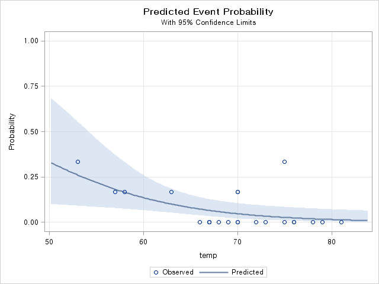

### 부록 - 자료

1. 문제 3번이 자료

```
x1 x2 y
45 2 0
40 4 1
60 3 0
50 2 0
55 2 0
50 5 1
35 7 1
65 10 1
53 2 0
48 1 0
37 5 1
31 7 1
40 4 0
75 8 1
43 9 1
49 2 0
37.5 4 1
71 11 1
34 5 0
27 6 1
```

2. O-ring 자료

```
/* 변수설명

temp: 이륙시 온도(Temperature at Liftoff)
trial: 실험 횟수
failed: 손상된 o-ring의 개수
*/

Data oring;
input trial failed temp ;
cards;
6 0 66
6 1 70
6 0 69
6 0 68
6 0 67
6 0 72
6 0 73
6 0 70
6 1 57
6 1 63
6 1 70
6 0 78
6 0 67
6 2 53
6 0 67
6 0 75
6 0 70
6 0 81
6 0 76
6 0 79
6 2 75
6 0 76
6 1 58
;
run;

proc logistic data=oring;
  model failed/trial = temp ;
run;
```